# UM PhD vacancy | UNIQUE project

Michelle de Groot

27 July, 2024

### Interview Assignment

In this test, we will be working with DNA methylation data obtained via Reduced Representation Bisulfite Sequencing (RRBS) from semen samples of males undergoing endurance training.  
Please follow the instructions and provide your answers to the questions below. Indications are included if you are using R, but feel free to use any other programming language to complete the test as you see fit.

Step 1: Go to Gene Expression Omnibus (GEO) and download the data with GEO ID: GSE109474 (GSE109474_methReads.csv.gz, GSE109474_predictedMeth.csv.gz and GSE109474_totalReads.csv.gz). These three files contain either the total number of reads, reads corresponding to the methylated epiallele or the predicted methylation ratio.

```r
#data folder
file_path <- "data/"

#download GSE109474_methReads.csv.gz
file_name <- "GSE109474_methReads.csv.gz"
if (!file.exists(paste0(file_path, file_name))){
  url <- "https://www.ncbi.nlm.nih.gov/geo/download/?acc=GSE109474&format=file&file=GSE109474%5FmethReads%2Ecsv%2Egz"
  download.file(url, paste(file_path, file_name, sep = ""), mode = "wb")
}

#download GSE109474_predictedMeth.csv.gz
file_name <- "GSE109474_predictedMeth.csv.gz"
if (!file.exists(paste0(file_path, file_name))){
  url <- "https://www.ncbi.nlm.nih.gov/geo/download/?acc=GSE109474&format=file&file=GSE109474%5FpredictedMeth%2Ecsv%2Egz"
  download.file(url, paste(file_path, file_name, sep = ""), mode = "wb")
}

#download GSE109474_totalReads.csv.gz
file_name <- "GSE109474_totalReads.csv.gz"
if (!file.exists(paste0(file_path, file_name))){
  url <- "https://www.ncbi.nlm.nih.gov/geo/download/?acc=GSE109474&format=file&file=GSE109474%5FtotalReads%2Ecsv%2Egz"
  download.file(url, paste(file_path, file_name, sep = ""), mode = "wb")
}

#Read methylation files
meth_reads <- data.table::fread("data/GSE109474_methReads.csv.gz")
predicted_meth <- data.table::fread("data/GSE109474_predictedMeth.csv.gz")
total_reads <- data.table::fread("data/GSE109474_totalReads.csv.gz")
```

**Q1) What is the experimental design of the study (number of samples per condition, replicates, controls)? What is the difference between RRBS and WGBS? Which restriction enzymes did they use in this assay and what are their target sequences?**

*Anwer*: Study setup is n=6 for sRNA and n=12 for RRBS. There are three timepoints where semen was sampled. T1 = Untrained (Starting point), T2 = Trained (5 days after 6 weeks of training), and T3 = Detrained (3 months after training). This study has no control group. However, they cite another study that did not measure significant differences in methylation levels in a 3-month interval for a non-exercising group. RRBS focusses on a subset of the genome (CpG islands), while WGBS covers the entire genome. They used MspI restriction enzymes, which targets 5’-CCGG-3’.

**Q2) Why does the predictedMeth file have a size of 146.0 Mb, while the methReads and totalReads files have a size of only 18.5 and 20.1 Mb?**  
*Answer*: Predicted contains much more bytes because the estimated reads are floats with many decimals. Of course, in the measured reads there are only integers.

```r
#Create a identifier vector combining chromosome start and end position with the following format: “chri:start-end”
meth_reads_matrix <-
  meth_reads %>% mutate(
  id = paste0(seqnames,":",start,"-",end)) %>%
  column_to_rownames("id") %>%
  select(-c(seqnames,cluster.id, start, end)) %>%
  as.matrix() # character instead of num?

total_reads_matrix <-
  total_reads %>% mutate(
  id = paste0(seqnames,":",start,"-",end)) %>%
  column_to_rownames("id") %>%
  select(-c(seqnames,cluster.id, start, end)) %>%
  as.matrix() # character instead of num?
```

**Compute the DNA methylation ratio.**  
First, explore the methReads and totalReads .csv files. When using R, you can import the methReads and totalReads .csv files (clue: it will be much faster if you use the function fread from the “data.table” R-package). The data contains 4 columns storing characters: “seqnames”, “start”, “end” and “cluster.id”. These will be a nuisance for any downstream analysis. Create a identifier vector combining chromosome start and end position with the following format: “chri:start-end”. Then, remove the 4 character columns from the imported matrices, convert to numeric matrix data type and use the created ID vector as row.names. Perform this processing step for both methReads and totalReads. Finally, compute DNA methylation ratio.

```r
meth_ratio = round((meth_reads_matrix / total_reads_matrix), 3)

#check
head(meth_ratio)  %>%
  kbl(caption = "Methylation ratio's") %>%
  kable_material(c("striped", "hover")) %>%
    kable_styling(full_width = F) %>%
    scroll_box(width = "100%")
```

Methylation ratio’s

|  | RRBS_11_1 | RRBS_11_2 | RRBS_11_3 | RRBS_14_1 | RRBS_14_2 | RRBS_14_3 | RRBS_15_1 | RRBS_15_2 | RRBS_15_3 | RRBS_16_1 | RRBS_16_2 | RRBS_16_3 | RRBS_17_1 | RRBS_17_2 | RRBS_17_3 | RRBS_18_1 | RRBS_18_2 | RRBS_18_3 | RRBS_24_1 | RRBS_24_2 | RRBS_24_3 | RRBS_27_1 | RRBS_27_2 | RRBS_27_3 | RRBS_5_1 | RRBS_5_2 | RRBS_5_3 | RRBS_7_1 | RRBS_7_2 | … |
| --- | --- | --- | --- | --- | --- | --- | --- | --- | --- | --- | --- | --- | --- | --- | --- | --- | --- | --- | --- | --- | --- | --- | --- | --- | --- | --- | --- | --- | --- | --- |
| chr6:209789-209789 | 0.050 | 0.091 | 0.024 | 0.083 | 0.097 | 0.02 | 0.053 | 0.000 | 0.263 | 0.089 | 0 | 0.273 | 0 | 0.062 | 0 | 0.047 | 0 | 0.071 | 0.045 | 0.059 | 0.061 | 0.167 | 0 | 0.167 | 0 | 0.00 | 0.2 | 0 | 0.000 | … |
| chr6:209809-209809 | 0.033 | 0.059 | 0.000 | 0.000 | 0.000 | 0.00 | 0.053 | 0.174 | 0.000 | 0.036 | 0 | 0.000 | 0 | 0.000 | 0 | 0.000 | 0 | 0.071 | 0.045 | 0.000 | 0.061 | 0.000 | 0 | 0.000 | 0 | 0.00 | 0.0 | 0 | 0.000 | … |
| chr6:209819-209819 | 0.033 | 0.059 | 0.000 | 0.000 | 0.000 | 0.00 | 0.053 | 0.087 | 0.000 | 0.036 | 0 | 0.000 | 0 | 0.000 | 0 | 0.000 | 0 | 0.071 | 0.045 | 0.000 | 0.061 | 0.000 | 0 | 0.000 | 0 | 0.00 | 0.0 | 0 | 0.000 | … |
| chr6:209857-209857 | 0.036 | 0.071 | 0.000 | 0.111 | 0.100 | 0.00 | 0.000 | 0.083 | 0.333 | 0.020 | 0 | 0.000 | NaN | 0.000 | 0 | 0.000 | 0 | 0.000 | 0.032 | 0.000 | 0.000 | 0.000 | 0 | 0.000 | 0 | 0.00 | 0.0 | 0 | 0.083 | … |
| chr6:209875-209875 | 0.036 | 0.000 | 0.000 | 0.000 | 0.000 | 0.00 | 0.000 | 0.083 | 0.333 | 0.020 | 0 | 0.000 | NaN | 0.000 | 0 | 0.000 | 0 | 0.182 | 0.032 | 0.000 | 0.000 | 0.286 | 0 | 0.000 | 0 | 0.00 | 0.0 | 0 | 0.083 | … |
| chr6:209896-209896 | 0.038 | 0.107 | 0.038 | 0.000 | 0.000 | 0.00 | 0.000 | 0.000 | 0.000 | 0.020 | 0 | 0.167 | NaN | 0.040 | 0 | 0.000 | 0 | 0.182 | 0.032 | 0.000 | 0.000 | 0.286 | 0 | 0.000 | 0 | 0.25 | 0.0 | 0 | 0.167 | … |

**Q3) Count the number of missing values (NAs) in the obtained methylation ratio matrix. How were the NAs originated in the methylation ratio? Clue: count the number of NAs in methReads and totalReads.**  
*Result*:

```r
na_values <- data.frame(
  na = c(sum(is.na(meth_ratio)),
         sum(is.na(total_reads_matrix)),
         sum(is.na(meth_reads_matrix))),
  zero = c(sum(colSums(meth_ratio == 0)),
           sum(colSums(total_reads_matrix == 0)),
           sum(colSums(meth_reads_matrix == 0))),
  row.names = c("Methylation ratio matrix", "Total reads matrix", "Methylation reads matrix")
)

na_values %>%
  kbl(caption = "Methylation ratio's") %>%
  kable_material(c("striped", "hover")) %>%
  kable_styling(full_width = F)
```

Methylation ratio’s

|  | na | zero |
| --- | --- | --- |
| Methylation ratio matrix | 9367080 | NA |
| Total reads matrix | 0 | 9367080 |
| Methylation reads matrix | 0 | 37402023 |

*Answer*: the methylation ratio matrix has 9367080 N/A values. As you can see, these don’t (directly) originate from either the methylation reads or total reads. Looking at zero values does give us an explanation. As the ratio is calculated by dividing methylated reads by total reads, the ratio will be N/A when you try to divide by 0. The missing values are the same as the zero values in the total reads matrix. For the methylation reads matrix, this is not an issue, as you can divide 0 by any number.

**Q4) Visualize the methylation density distribution for each sample in a single plot. You may employ the convenient densityPlot function from the minfi R-package. Attach the resulting figure and comment about it.**  
*Answer*: The density plot shows the distribution of the methylation beta values for each sample (in this case). These values are, as expected, centered around 0 and 1, where 0 indicates unmethylated sites and 1 indicates methylates sites. This is an important step in the QC as a distribution that deviates from this distribution may be caused by poor quality of the data or other errors. There appears to be one sample with a different beta value distribution. We should investigate whether this is because of biological or technical variation.  
(The paper mentions that Sample 17_1 was sequenced less deeply and did not appear to be an outlier)

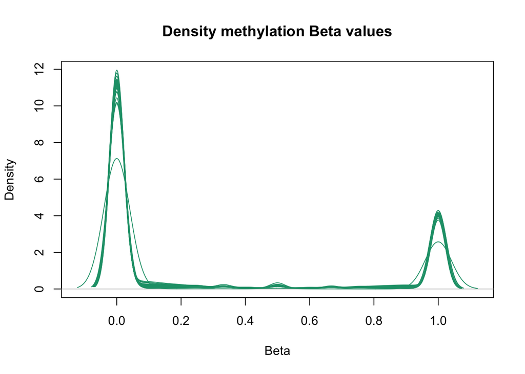

```r
densityPlot(meth_ratio, main = "Density methylation Beta values")
```

**Q5) Perform a multi-dimensional scaling (MDS) plot on the top 1000 most variable positions. You may employ the mdsPlot function from the minfi R-package. Employ the rainbow palette to colour each individual differently, use the filled circle point shape and display the legend in three columns. Describe briefly the basis of an MDS plot, attach and interpret the obtained visualization.** *Extra points: label each axis with the percentage of variance explained.*  
*Answer*: An MDS plot is a 2-d visualization of distances between samples. It uses Multidimensional Scaling, which is a form of dimensionality reduction. The minfi MDSPlot function used Euclidean distance to determine the distance between samples based on the most variable CpG positions.  
Each dot in the plot represents one sample, and each individual is indicated by color. There is one outlier for one of the samples from RRBS_17, which could be caused by biological or technical differences. (Again: The paper mentions that Sample 17_1 was sequenced less deeply and did not appear to be an outlier)

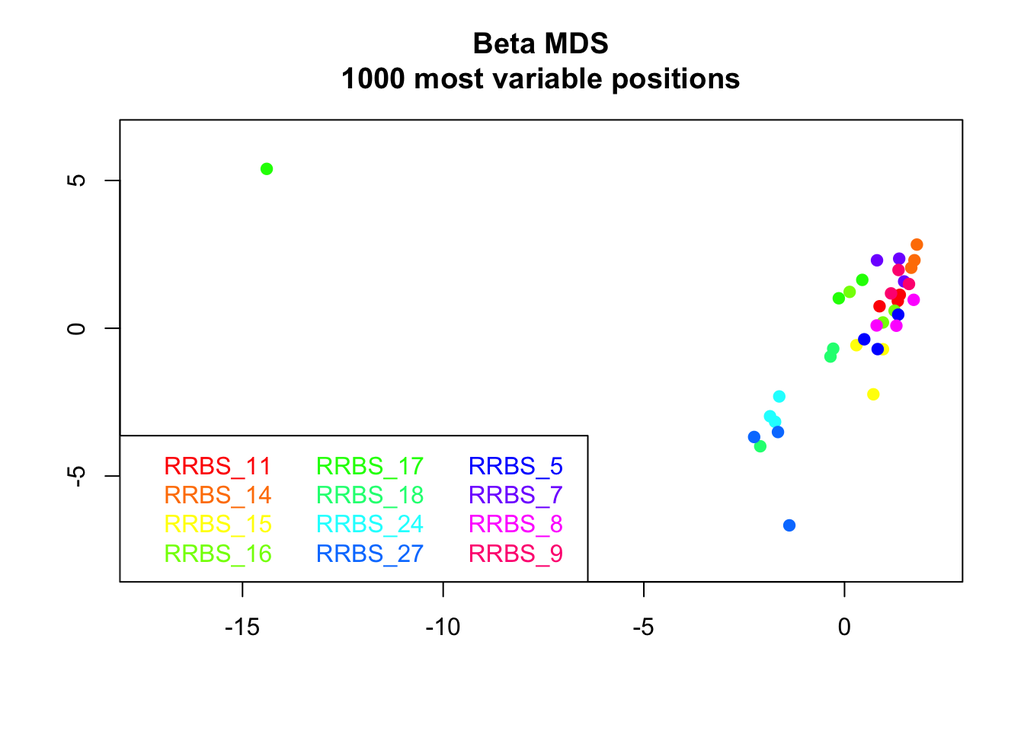

```r
samp_names <- colnames(meth_ratio)
# Extract the individual
individuals <- sub("_(\\d+)$", "", samp_names)


mdsPlot(meth_ratio, sampGroups = individuals, pch = 19, pal = rainbow(length(unique((individuals)))),
        legendPos = "bottomleft", legendNCol = 3)
```

**Q6) Extract all positions included in the region chr12:739000-740500, that corresponds to a strong methylation quantitative trait locus (meQTL). How many positions are included in this region? Visualize the data in these positions via heatmap. Use the heatmap.2 function from the R-package gplots. Use ColSideColors argument to add a colour guide in which each individual has a different colour. Describe and interpret the output.**  
*Answer*: There are 20 positions included in this region. Some samples have high missingness in this region and most sites are unmethylated. Most individuals or timepoints are not closely clustered in the dendogram. The fact that there is little variation in this region could indicate multiple things. For instance that this is a stable region, or that the methylation state is tissue specific (in this case spermatozoa).

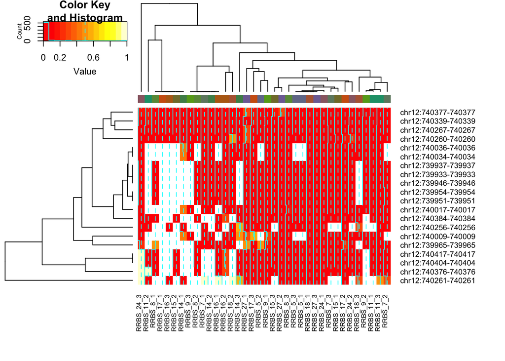

```r
meQTL_CpGs <- meth_reads %>%
  filter(seqnames == "chr12" & start >= 739000 & end <= 740500) %>%
  mutate(id = paste0(seqnames,":",start,"-",end)) %>%
  select(id)

meth_ratio_meQTL_CpGs <-
  subset(meth_ratio, rownames(meth_ratio) %in% meQTL_CpGs$id)

#create colors
individuals <- factor(individuals, levels = unique(individuals))
palette <- colorRampPalette(my_palette)(12)


heatmap.2(meth_ratio_meQTL_CpGs, ColSideColors = palette[individuals], margins=c(8,12))
```

Now, import predictedMeth .csv file in R (again with the “data.table” R-package) and perform the same processing as for methReads and totalReads .csv files (e.g. remove character columns and add as row.names and identifier to each position as in “chri:start-end”. You may round the matrix to 3 decimals to reduce storage resources.

**Q7) Extract the methylation values for the row corresponding to “chr6:209819-209819” from “predictedMeth.csv”. Plot this row vector against the methylation ratio we manually computed in the prior section for this same row. Does anything strike from the visualization? Explain why this is so. How does the densityPlot look for “predictedMeth.csv”? Use again the function densityPlot from the minfi R-package. Comment on the output plot.**  
*Answer*: When comparing the predicted and calculated methylation scores, we would expect a linear correlation. For the non-zero calculated methylation scores, this looks to be the case (with small variations). We also see samples where the calculated methylation ratio is zero, while the predicted methylation score is higher (but still in the unmethylated range). This could indicate measurement errors or low coverage in sequencing (for this position, coverage is between 3-61). A more likely explanation is that, where the calculated beta ratio returns 0 for no methylated reads, the prediction method is less likely to output exact zero values. Many predictive models, especially those based on regression techniques, predict values within a range but rarely exactly at zero. The density plot shows a clear bimodal distribution with two prominent peaks. One peak is near zero, indicating CpG sites that have very low or no methylation. The second peak is close to one, indicating CpG sites that are fully methylated. While the density around 0 and 1 appears to be similar to the calculated beta values, there are no small peaks in between. This suggests that the calculated values capture more variability in methylation states. The prediction model might be over-smoothing or not capturing the full range of intermediate methylation levels accurately.

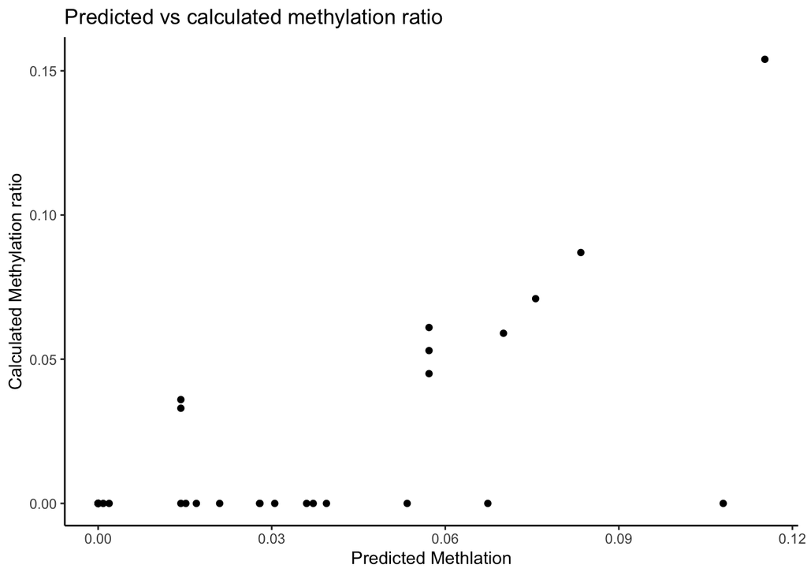

```r
# predicted meth al eerder ingelezen
#wel nog aanpassen rownames
predicted_meth_matrix <-
  predicted_meth %>% mutate(
  id = paste0(seqnames,":",start,"-",end)) %>%
  column_to_rownames("id") %>%
  select(-c(seqnames,cluster.id, start, end)) %>%
  as.matrix()

predicted_meth_chr6_209819 <-
  subset(predicted_meth_matrix, rownames(predicted_meth_matrix) == "chr6:209819-209819")
meth_ratio_chr6_209819 <-
  subset(meth_ratio, rownames(meth_ratio) == "chr6:209819-209819")

#check if order is the same
#colnames(predicted_meth_chr6_209819) == colnames(meth_ratio_chr6_209819)

ggplot() +
  geom_point(aes(x = predicted_meth_chr6_209819[1,], y = meth_ratio_chr6_209819[1,])) +
  xlab("Predicted Methlation") +
  ylab("Calculated Methylation ratio") +
  ggtitle("Predicted vs calculated methylation ratio") +
  theme_classic()
```

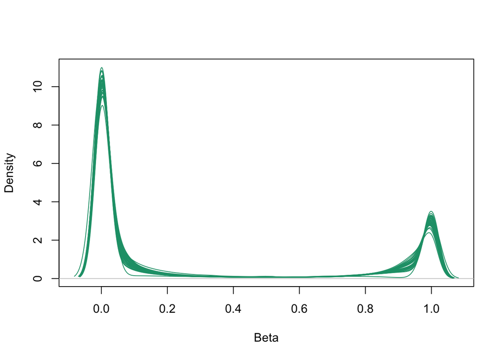

```r
densityPlot(predicted_meth_matrix)
```